# R Notebook

```r
setwd('/home/daria/Rprojects/LV_SC_project/')
.libPaths('/home/daria/Rprojects/single-cell-pipeline/project_packages/')
source('/home/daria/Rprojects/single-cell-pipeline/functions/process-utils.R')
source('/home/daria/Rprojects/single-cell-pipeline/functions/cluster-functions.R')
source('/home/daria/Rprojects/single-cell-pipeline/functions/viper-utils.R')
library(ggplot2)
library(ggpubr)
library(viper)
library(pheatmap)
library(RColorBrewer)
library(MUDAN)
library(umap)
```

### Master regulators analysis

To infer master regulators (MRs) involved in cell state transition during atherosclerosis development, we applied metaVIPER28, 29 on the ZsGreen1+ scRNA-seq data of Ldlr-/- mice fed 16-week WD, following the pipeline designed for MRs inference in scRNA-seq (https://github.com/califano-lab/single-cell-pipeline). Briefly, we first built a regulatory network using ARACNe on all single cells. ARACNe was run separately on each set of regulators: 1458 transcription factors, 821 transcriptional cofactors, and 3193 signaling proteins in mouse.

```r
raw.mat <- read.table('/home/daria/Rprojects/LV_SC_project/RPS007_matrix.txt',header = T,row.names = 1)
mur.mt <-  read.table('/home/daria/Rprojects/LV_SC_project/murine_mito_genes.csv', header = T, sep = ',', stringsAsFactors = FALSE) # http://asia.ensembl.org/biomart/martview/b2b79163486788b39f300cc958d90092
mur.mt <- mur.mt$mur.symb
mt.mat <- MTFilter(raw.mat,mur.mt)
```

```
## [1] "Removed 1 cells with too many MT reads"
```

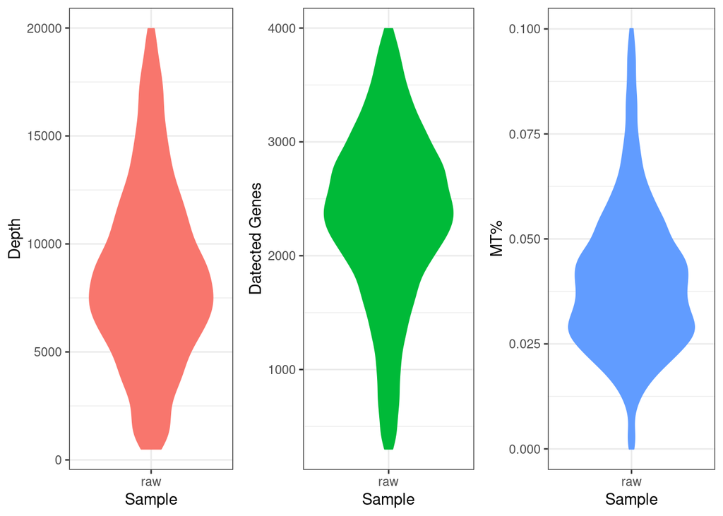

```r
QCPlots(raw.mat, mur.mt)
```

```r
filt.mat <- QCTransform(mt.mat)
```

```
## [1] "Removed 0 genes and 71 cells."
```

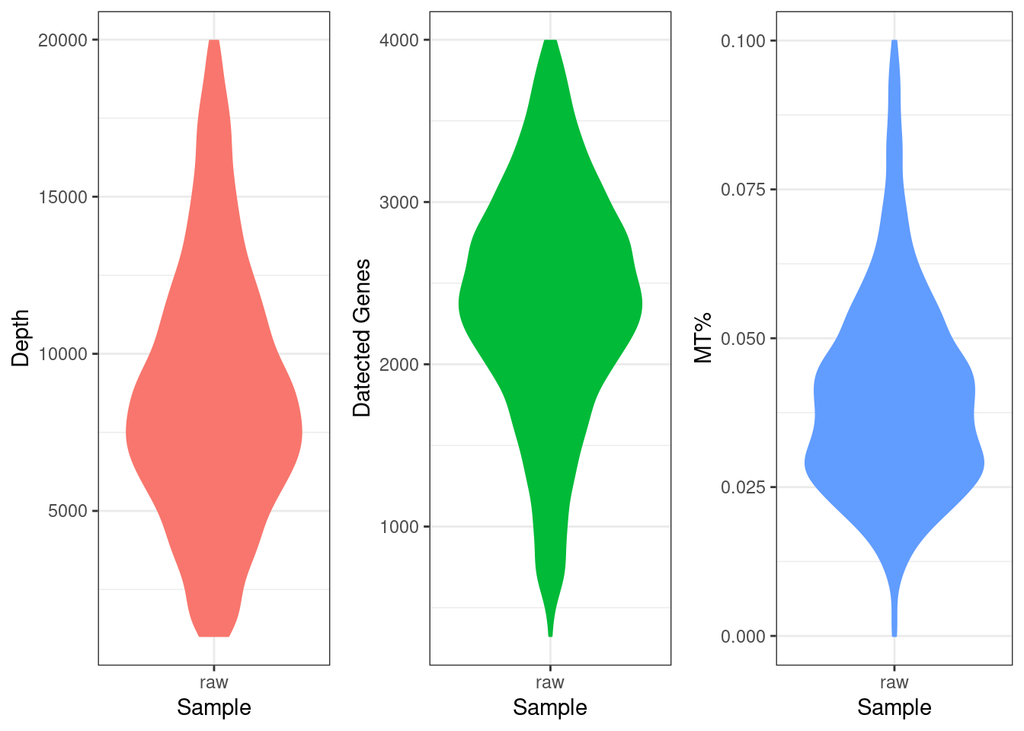

```r
QCPlots(filt.mat, mur.mt)
```

```r
# run these if data was not normalized or rank-transformed
cpm.mat <- CPMTransform(filt.mat)
rank.mat <- RankTransform(cpm.mat)

# if was:
#rank.mat = as.matrix(raw.mat)
```

```
bash ./run_aracne.sh
```

Gene expression signature was generated on each cell using the median gene expression as internal reference.

```r
netw_file = "/home/daria/Rprojects/LV_SC_project/merged_net.tsv"
RegProcess(netw_file, rank.mat, out.dir = '/home/daria/Rprojects/LV_SC_project/ARACNA_out_2/', out.name = 'pbmc_r1-net-')
```

```
##
## Loading the dataset...
```

```
## Generating the regulon objects...
```

```
## number of iterations= 94
```

```
## mu: -0.41208642187274, 0, 0.257533517476728. sigma: 0.0148231811941705, 0.061794534118577, 0.276811664602183
```

```r
r1.net <- readRDS('/home/daria/Rprojects/LV_SC_project/ARACNA_out/pbmc_r1-net-pruned.rds')
r1.pAct <- viper(rank.mat, r1.net, method = 'mad')
```

```
##
## Computing the association scores
```

```
## Computing regulons enrichment with aREA
```

We then inferred protein activity based on the combined regulatory network and gene expression signature.

Partitioning around medoids (PAM) clustering was applied to distance matrix built on protein activity with the number of clusters ranging from 2 to 10.

```r
r1.viperDist <- as.dist(viperSimilarity(r1.pAct))
r1.clusts <- PamKRange(r1.viperDist, kmin = 2, kmax = 10)
```

```
## [1] "Clustering with k=2..."
## [1] "Clustering with k=3..."
## [1] "Clustering with k=4..."
## [1] "Clustering with k=5..."
## [1] "Clustering with k=6..."
## [1] "Clustering with k=7..."
## [1] "Clustering with k=8..."
## [1] "Clustering with k=9..."
## [1] "Clustering with k=10..."
```

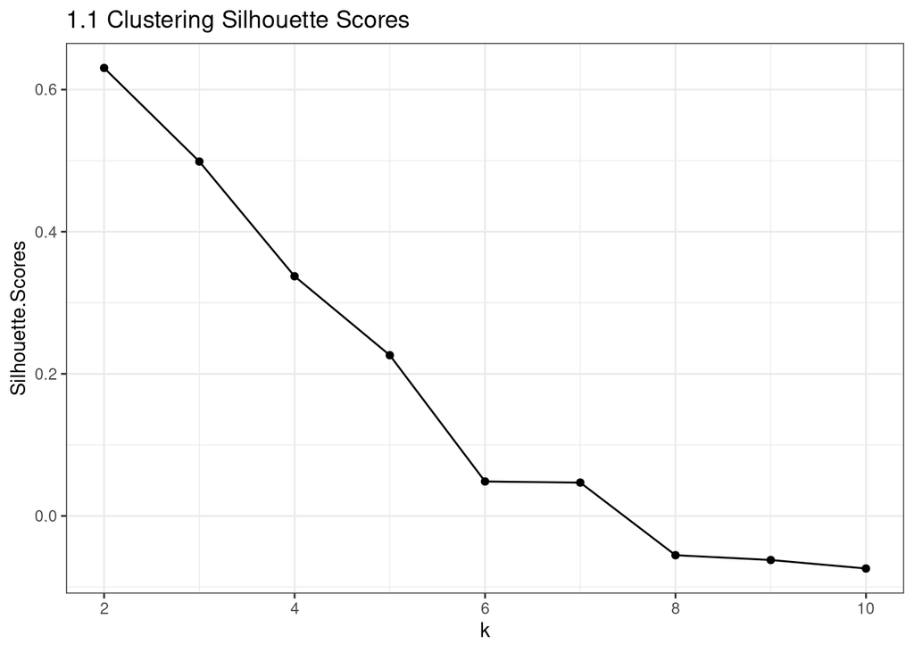

```r
r1.clustSil <- SilScoreEval(r1.clusts, r1.viperDist)
plot.dat <- data.frame('k' = 2:10, 'Silhouette.Scores' = r1.clustSil)
ggplot(plot.dat, aes(x = k, y = Silhouette.Scores)) + geom_point() + geom_line() +
  ggtitle('1.1 Clustering Silhouette Scores') + theme_bw()
```

Next, we generated cluster-specific ARACNe networks using meta-cell profiles built from integrating gene expression profiles of cells with similar protein activity profiles within each cluster. Counts from 5 nearest cells were integrated to generate each meta-cell.

```r
r1.clustMats <- MakeCMfA(rank.mat, r1.viperDist, clustering = r1.clusts$k6, out.dir = '/home/daria/Rprojects/LV_SC_project/', out.name = 'pbmc-r1-clusts')
```

```
## [1] 5
```

Protein activity was inferred again using cluster-specific networks as input to VIPER.

```r
c1.net <- RegProcess(netw_file , r1.clustMats[[1]],
                     out.dir = '/home/daria/Rprojects/LV_SC_project/', out.name = 'pbmc-r2-c1_')
```

```
##
## Loading the dataset...
```

```
## Generating the regulon objects...
```

```
## number of iterations= 81
```

```
## mu: -0.553232465992368, 0, 0.637475638322675. sigma: 0.0607384320604711, 0.219270763875936, 0.194328235018094
```

```r
c2.net <- RegProcess(netw_file , r1.clustMats[[2]],
                     out.dir = '/home/daria/Rprojects/LV_SC_project/', out.name = 'pbmc-r2-c2_')
```

```
##
## Loading the dataset...
## Generating the regulon objects...
```

```
## WARNING! NOT CONVERGENT!
## number of iterations= 1000
## WARNING! NOT CONVERGENT!
## number of iterations= 1000
## number of iterations= 550
```

```
## mu: 0.131447071871722, 0, 0.183536578965752. sigma: 0.0762068142103136, 0.167163494852404, 0.210624512705052
```

```r
c3.net <- RegProcess(netw_file , r1.clustMats[[3]],
                     out.dir = '/home/daria/Rprojects/LV_SC_project/', out.name = 'pbmc-r2-c3_')
```

```
##
## Loading the dataset...
## Generating the regulon objects...
```

```
## WARNING! NOT CONVERGENT!
## number of iterations= 1000
## WARNING! NOT CONVERGENT!
## number of iterations= 1000
## WARNING! NOT CONVERGENT!
## number of iterations= 1000
```

```
## mu: -0.223604816373493, 0, 0.213039823510601. sigma: 0.13510827959884, 0.172607471655941, 0.190633475581707
```

```r
# load in networks
c1.net <- readRDS('/home/daria/Rprojects/LV_SC_project//pbmc-r2-c1_pruned.rds')
c2.net <- readRDS('/home/daria/Rprojects/LV_SC_project//pbmc-r2-c2_pruned.rds')
c3.net <- readRDS('/home/daria/Rprojects/LV_SC_project//pbmc-r2-c3_pruned.rds')
# infer protein activity
r2.pAct <- viper(rank.mat, list('c1' = c1.net, 'c2' = c2.net, 'c3' = c3.net), method = 'none')
```

```
##
## Computing the association scores
```

```
## Computing regulons enrichment with aREA
```

```r
r2.cbcMRs <- CBCMRs(r2.pAct) # identify the most representative proteins
r2.pAct.cbc <- r2.pAct[r2.cbcMRs ,] # filter the protein activity matrix
r2.louvain <- LouvainClust(r2.pAct.cbc) # perform clustering analysis

r2.MRs <- BTTestMRs(r2.pAct, r2.louvain, bootstrap.num = 100)
```

```
## [1] "Identifying MRs for cluster 1..."
## [1] "Identifying MRs for cluster 2..."
## [1] "Identifying MRs for cluster 3..."
## [1] "Identifying MRs for cluster 4..."
## [1] "Identifying MRs for cluster 5..."
## [1] "Identifying MRs for cluster 6..."
## [1] "Identifying MRs for cluster 7..."
## [1] "Identifying MRs for cluster 8..."
## [1] "Identifying MRs for cluster 9..."
## [1] "Identifying MRs for cluster 10..."
## [1] "Identifying MRs for cluster 11..."
```

Top activated and repressed MRs and their target genes are visualized using Cytoscape v3.3.0.

```r
Top.MRS = MR_UnWrap(r2.MRs, top = 10)
#--> Cytoscape
```

## Data visualisation and annotation

Umap

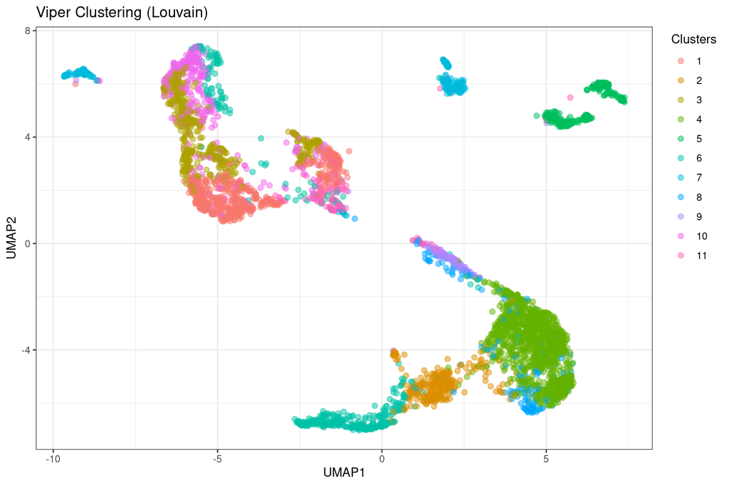

```r
r2.cbcUMAP <- CustomUMAP(r2.pAct.cbc)
plot=ClusterScatter(r2.cbcUMAP, r2.louvain, 'Viper Clustering (Louvain)')
plot
```

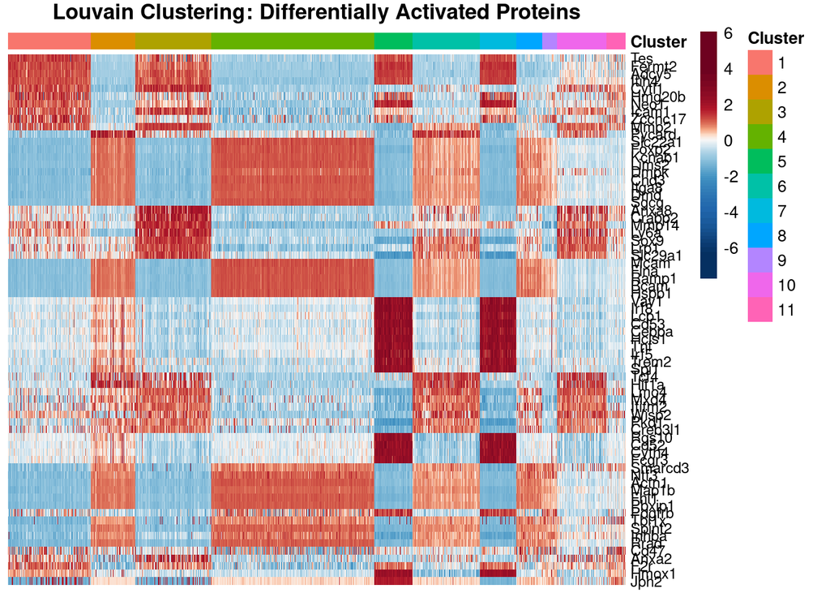

```r
ClusterHeatmap(r2.pAct[ MR_UnWrap(r2.MRs, top = 10) , ], clust = r2.louvain, plotTitle = 'Louvain Clustering: Differentially Activated Proteins')
```

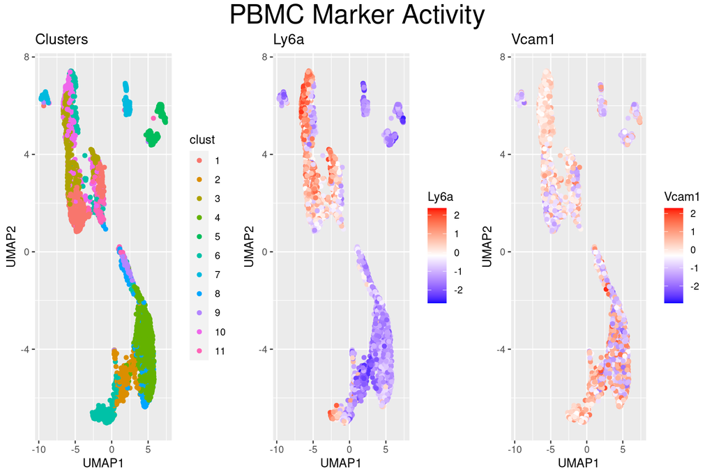

```r
markers <- c('Ly6a', 'Vcam1', 'Ly6c1') # markers of stem cells, endothelial cells, monocytes/macrophages differentiation (expected to be enriched in SMC derived cells)
MarkerGrid(r2.cbcUMAP, r2.louvain, r2.pAct, markers, 'PBMC Marker Activity')
```

SingleR

```r
library(SingleR)
library(celldex)
ref.data <- MouseRNAseqData(cell.ont="nonna")
```

```
## snapshotDate(): 2022-10-31
```

```
## see ?celldex and browseVignettes('celldex') for documentation
```

```
## loading from cache
```

```
## see ?celldex and browseVignettes('celldex') for documentation
```

```
## loading from cache
```

```r
predictions <- SingleR(test=rank.mat, assay.type.test=1,
    ref=ref.data, labels=ref.data$label.main)
table(predictions$labels)
```

```
##
##        Adipocytes        Astrocytes           B cells    Cardiomyocytes
##                21                 7                 3               618
##   Dendritic cells Endothelial cells  Epithelial cells      Erythrocytes
##                88                50                12                11
##       Fibroblasts      Granulocytes       Hepatocytes       Macrophages
##               856               413                52               107
##         Microglia         Monocytes           Neurons          NK cells
##                11               163              1667                 7
##           T cells
##               129
```

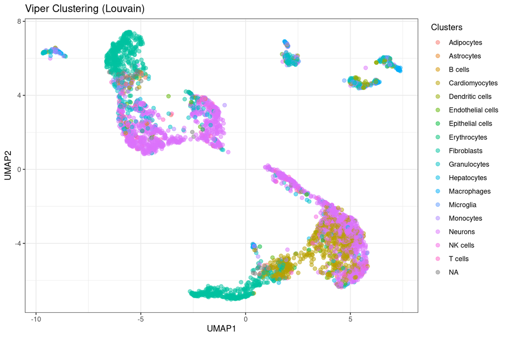

```r
plot=ClusterScatter(r2.cbcUMAP, predictions$pruned.labels, 'Viper Clustering (Louvain)')
plot
```

## notes:

1. Networks can be improved if use combined RNA-seq data and scRNAseq data.
2. Annotation can be improved if use data from Wirke 2019 (it is here: https://app.globus.org, search for ‘Plaqview’ public dataset); blocker – need to request access to download data, though it is written as it is ‘Public’
3. Data from viper can be visualized in Seurat package. And combined with human data.